# Przetwarzanie danych w R i Python

Praca domowa nr 1

Antoni Chudy

18-04-2024

# Wstęp

Raport przedstawia wyniki otrzymane podczas realizacji pracy domowej, której celem było rozwiązanie pięciu zadań. Każde z nich polegało na napisaniu podanych zapytań w języku SQL używając:

- *funkcji bazowych języka R*
- *pakietu dplyr*
- *pakietu data.table*

Poprawność uzyskanych wyników zostanie zbadana za pomocą funkcji *compare*. Ponadto dla wszystkich czterech sposobów rozwiązania każdego zadania zostaną porównane czasy ich wykonania za pomocą pakietu *microbenchmark*.

`Wczytanie danych, kodu źródłowego, odpowiednich pakietów.`

```r
library(compare)
library(microbenchmark)
library(sqldf)
library(dplyr)
library(data.table)
source("Chudy_Antoni_313476_pd1.R")
```

```r
Comments <- read.csv("Comments.csv.gz")
Posts <- read.csv("Posts.csv.gz")
PostLinks <- read.csv("PostLinks.csv.gz")
Users <- read.csv("Users.csv.gz")
CommentsDT <- data.table(Comments)
PostsDT <- data.table(Posts)
UsersDT <- data.table(Users)
PostLinksDT <- data.table(PostLinks)
```

## Zapytanie 1

### Porównanie otrzymanych wyników

```r
compare(sqldf_1(Posts, Users), base_1(Posts, Users), allowAll = TRUE)
```

```
## TRUE
```

```r
compare(sqldf_1(Posts, Users), dplyr_1(Posts, Users), allowAll = TRUE)
```

```
## TRUE
```

```r
compare(sqldf_1(Posts, Users), data.table_1(PostsDT, UsersDT), allowAll = TRUE)
```

```
## TRUE
##   dropped attributes
```

### Oszacowanie czasowe

```r
time1 <- microbenchmark::microbenchmark(

  sqldf = sqldf_1(Posts, Users),
  base = base_1(Posts, Users),
  dplyr = dplyr_1(Posts, Users),
  data.table = data.table_1(PostsDT, UsersDT),
  times = 40
)
print(time1)
```

```
## Unit: milliseconds
##        expr      min       lq      mean    median        uq      max neval
##       sqldf 702.2303 732.1949 764.26315 756.38045 789.54565 904.8712    40
##        base 397.3260 475.0161 514.15659 493.83695 530.12280 817.1195    40
##       dplyr  91.8040 104.6559 158.37690 159.05405 174.25440 386.3057    40
##  data.table  51.8675  56.4982  83.66544  61.54665  66.90005 325.0878    40
```

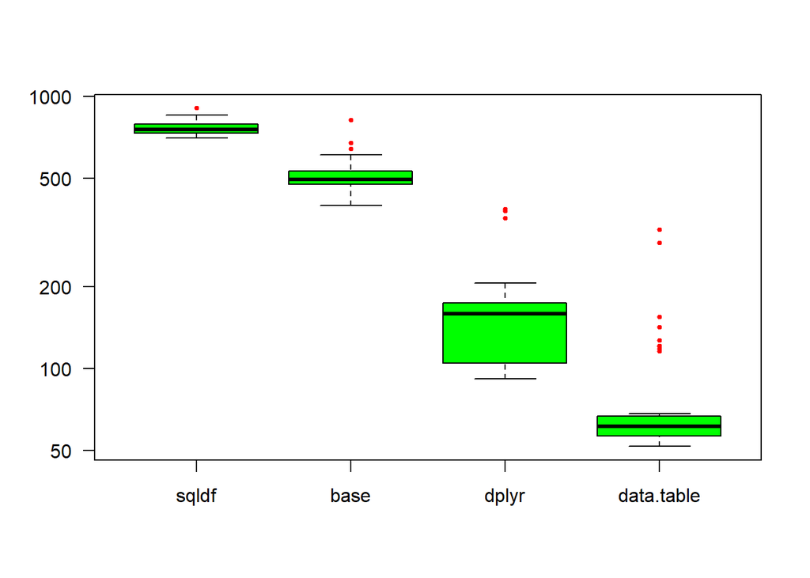

```r
boxplot(time1, col = "green", outcol = "red", xlab = "", ylab = "", las = 1, cex = 0.5, pch = 19)
```

### Opis

Liczymy użytkowników dla różnych wartości lokalizacji (pomijamy pustą wartość lokalizacji). Następnie zwracamy 10 lokalizacji z największą liczbą użytkowników.

## Zapytanie 2

### Porównanie otrzymanych wyników

```r
compare(sqldf_2(Posts, PostLinks), base_2(Posts, PostLinks), allowAll = TRUE)
```

```
## TRUE
```

```r
compare(sqldf_2(Posts, PostLinks), dplyr_2(Posts, PostLinks), allowAll = TRUE)
```

```
## TRUE
##   dropped attributes
```

```r
compare(sqldf_2(Posts, PostLinks), data.table_2(PostsDT, PostLinksDT), allowAll = TRUE)
```

```
## TRUE
##   dropped attributes
```

### Oszacowanie czasowe

```r
time2 <- microbenchmark::microbenchmark(

  sqldf = sqldf_2(Posts, PostLinks),
  base = base_2(Posts, PostLinks),
  dplyr = dplyr_2(Posts, PostLinks),
  data.table = data.table_2(PostsDT, PostLinksDT),
  times = 40
)
print(time2)
```

```
## Unit: milliseconds
##        expr      min        lq      mean   median       uq      max neval
##       sqldf 484.5864 492.20015 504.53052 494.6274 507.2373 588.2801    40
##        base 165.4016 167.15150 173.25867 169.1900 171.5638 217.0824    40
##       dplyr  71.5281  73.35225  93.10413  75.2427 124.7364 167.5135    40
##  data.table  14.6086  17.50010  18.25275  18.7043  19.1842  23.1301    40
```

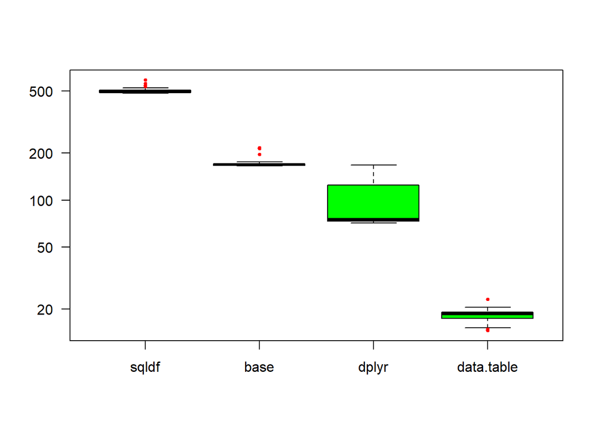

```r
boxplot(time2, col = "green", outcol = "red", xlab = "", ylab = "", las = 1, cex = 0.5, pch = 19)
```

### Opis

Dla postów typu pytanie znajdujemy tytuły postów oraz związaną z nimi liczbę linków. Następnie zwracamy je w porządku malejącym według liczby powiązań (linków).

## Zapytanie 3

### Porównanie otrzymanych wyników

```r
compare(sqldf_3(Comments, Posts, Users), base_3(Comments, Posts, Users), allowAll = TRUE)
```

```
## TRUE
```

```r
compare(sqldf_3(Comments, Posts, Users), dplyr_3(Comments, Posts, Users), allowAll = TRUE)
```

```
## TRUE
##   dropped attributes
```

```r
compare(sqldf_3(Comments, Posts, Users), data.table_3(CommentsDT, PostsDT, UsersDT), allowAll = TRUE)
```

```
## TRUE
##   dropped attributes
```

### Oszacowanie czasowe

```r
time3 <- microbenchmark::microbenchmark(

  sqldf = sqldf_3(Comments, Posts, Users),
  base = base_3(Comments, Posts, Users),
  dplyr = dplyr_3(Comments, Posts, Users),
  data.table = data.table_3(CommentsDT, PostsDT, UsersDT),
  times = 40
)
print(time3)
```

```
## Unit: milliseconds
##        expr       min         lq      mean    median        uq       max neval
##       sqldf 1038.3065 1051.48555 1076.5613 1070.5987 1094.7984 1203.7200    40
##        base 1521.9707 1555.27100 1598.7858 1590.0183 1624.7276 1848.4076    40
##       dplyr  294.0761  310.44045  354.3664  333.0616  372.6648  607.0668    40
##  data.table   91.7080   99.32185  122.4543  101.7869  150.1661  362.0128    40
```

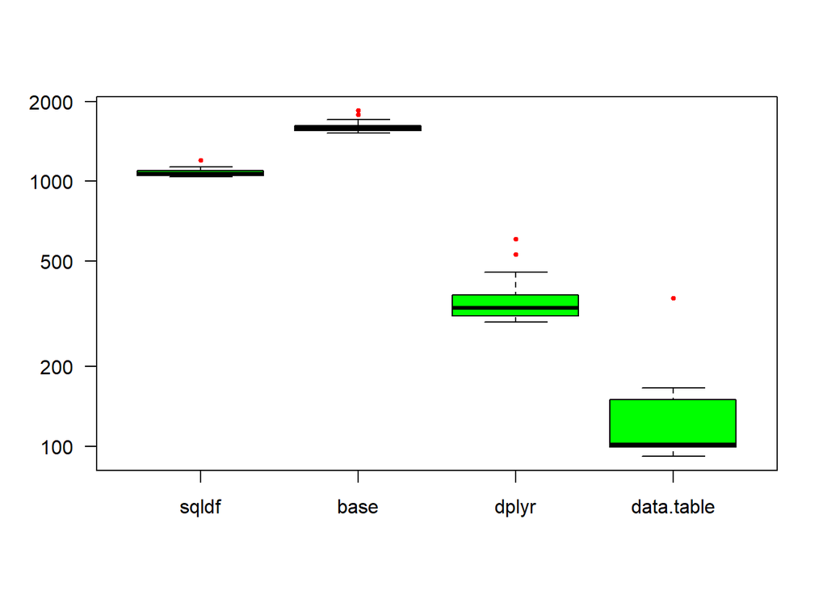

```r
boxplot(time3, col = "green", outcol = "red", xlab = "", ylab = "", las = 1, cex = 0.5, pch = 19)
```

### Opis

Znajdujemy 10 postów o największym łącznym wyniku z komentarzy. Dla tak znalezionych postów zwracamy związaną z nimi liczbę wyświetleń, liczbę komentarzy, tytuł, nazwę autora, jego ocenę na forum, miejsce z którego pochodzi oraz łączny wynik z wszystkich komentarzy dla danego posta.

## Zapytanie 4

### Porównanie otrzymanych wyników

```r
compare(sqldf_4(Posts, Users), base_4(Posts, Users), allowAll = TRUE)
```

```
## TRUE
```

```r
compare(sqldf_4(Posts, Users), dplyr_4(Posts, Users), allowAll = TRUE)
```

```
## TRUE
##   dropped attributes
```

```r
compare(sqldf_4(Posts, Users), data.table_4(PostsDT, UsersDT), allowAll = TRUE)
```

```
## TRUE
##   dropped attributes
```

### Oszacowanie czasowe

```r
time4 <- microbenchmark::microbenchmark(

  sqldf = sqldf_4(Posts, Users),
  base = base_4(Posts, Users),
  dplyr = dplyr_4(Posts, Users),
  data.table = data.table_4(PostsDT, UsersDT),
  times = 40
)
print(time4)
```

```
## Unit: milliseconds
##        expr      min        lq      mean   median       uq      max neval
##       sqldf 704.7217 710.80360 729.52676 715.7238 740.0538 813.1393    40
##        base 839.6806 860.44035 873.61190 866.4838 883.9075 946.1179    40
##       dplyr 336.9792 346.49260 387.64999 363.9877 408.0955 675.6482    40
##  data.table  24.7306  27.15375  31.72935  27.9489  28.4992  80.6837    40
```

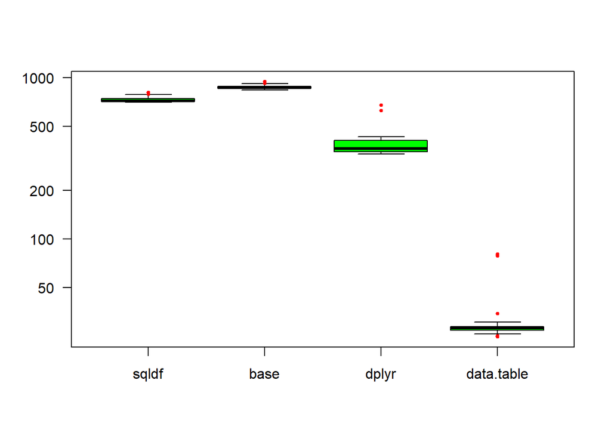

```r
boxplot(time4, col = "green", outcol = "red", xlab = "", ylab = "", las = 1, cex = 0.5, pch = 19)
```

### Opis

Znajdujemy użytkowników, którzy udzielają więcej odpowiedzi niż zadają pytań na forum, spośród nich wybieramy pięciu, którzy udzielają najwięcej odpowiedzi. Dla tak znalezionych pięciu użytkowników znajdujemy ich nazwę, łączną liczbę zadanych pytań, udzielonych odpowiedzi, ich lokalizację, reputację, łączną liczbę głosów za i przeciw.

## Zapytanie 5

### Porównanie otrzymanych wyników

```r
compare(sqldf_5(Posts, Users), base_5(Posts, Users), allowAll = TRUE)
```

```
## TRUE
```

```r
compare(sqldf_5(Posts, Users), dplyr_5(Posts, Users), allowAll = TRUE)
```

```
## TRUE
##   dropped attributes
```

```r
compare(sqldf_5(Posts, Users), data.table_5(PostsDT, UsersDT), allowAll = TRUE)
```

```
## TRUE
##   dropped attributes
```

### Oszacowanie czasowe

```r
time5 <- microbenchmark::microbenchmark(

  sqldf = sqldf_5(Posts, Users),
  base = base_5(Posts, Users),
  dplyr = dplyr_5(Posts, Users),
  data.table = data.table_5(PostsDT, UsersDT),
  times = 40
)
print(time5)
```

```
## Unit: milliseconds
##        expr      min        lq      mean   median       uq       max neval
##       sqldf 794.4412 801.06350 825.14337 814.5203 824.9412 1100.3212    40
##        base 728.2267 789.52405 815.33789 800.6396 809.3081 1093.8194    40
##       dplyr 453.1386 509.79230 524.83204 529.2871 543.6411  619.0886    40
##  data.table  45.1267  49.10415  53.10407  50.4029  51.5146  110.3934    40
```

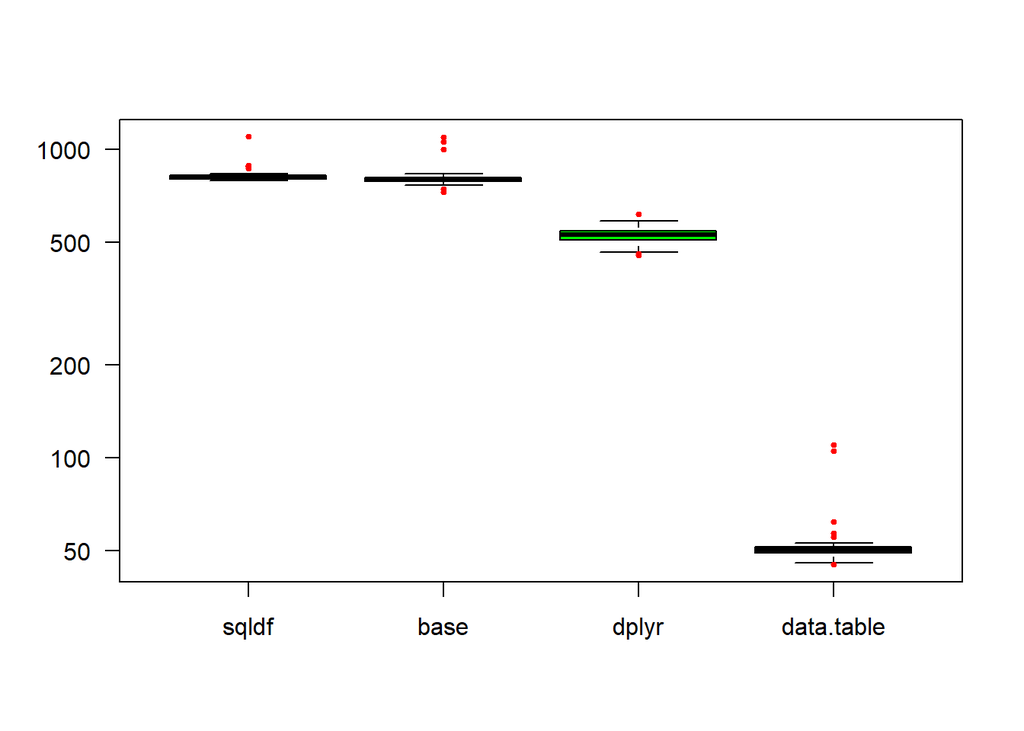

```r
boxplot(time5, col = "green", outcol = "red", xlab = "", ylab = "", las = 1, cex = 0.5, pch = 19)
```

### Opis

W pierwszym kroku znajdujemy liczbę odpowiedzi dla każdego posta. Następnie obliczamy średnią liczbę odpowiedzi dla użytkowników, sortujemy wyniki malejąco po średniej liczbie postów stworzonych przez danego użytkownika. Kolejno wybieramy 10 pierwszych użytkowników z ich nazwą, lokalizacją, numerem w bazie oraz średnią stworzoną przez nich liczbą postów.

# Podsumowanie

Wyniki otrzymane za pomocą funkcji *microbenchmark* pokazują, że zapytania napisane z wykorzystaniem *pakietu data.table* wykonują się w najkrótszym czasie. Możemy zauważyć, że *pakiet dplyr* pozwala na uzyskanie rozwiązań w czasie krótszym od rozwiązań referencyjnych w SQL oraz funkcji bazowych. Według mnie najbardziej przyjemny do pracy z danymi jest *pakiet dplyr*.